# Bikeshare

#### Reading the datasets

```r
nyc= read.csv('new-york-city.csv')
```

```r
head(nyc)
```

| X | Start.Time | End.Time | Trip.Duration | Start.Station | End.Station | User.Type | Gender | Birth.Year |
| --- | --- | --- | --- | --- | --- | --- | --- | --- |
| 5688089 | 2017-06-11 14:55:05 | 2017-06-11 15:08:21 | 795 | Suffolk St & Stanton St | W Broadway & Spring St | Subscriber | Male | 1998 |
| 4096714 | 2017-05-11 15:30:11 | 2017-05-11 15:41:43 | 692 | Lexington Ave & E 63 St | 1 Ave & E 78 St | Subscriber | Male | 1981 |
| 2173887 | 2017-03-29 13:26:26 | 2017-03-29 13:48:31 | 1325 | 1 Pl & Clinton St | Henry St & Degraw St | Subscriber | Male | 1987 |
| 3945638 | 2017-05-08 19:47:18 | 2017-05-08 19:59:01 | 703 | Barrow St & Hudson St | W 20 St & 8 Ave | Subscriber | Female | 1986 |
| 6208972 | 2017-06-21 07:49:16 | 2017-06-21 07:54:46 | 329 | 1 Ave & E 44 St | E 53 St & 3 Ave | Subscriber | Male | 1992 |
| 1285652 | 2017-02-22 18:55:24 | 2017-02-22 19:12:03 | 998 | State St & Smith St | Bond St & Fulton St | Subscriber | Male | 1986 |

```r
chicago= read.csv('chicago.csv')
```

```r
head(chicago)
```

| X | Start.Time | End.Time | Trip.Duration | Start.Station | End.Station | User.Type | Gender | Birth.Year |
| --- | --- | --- | --- | --- | --- | --- | --- | --- |
| 1423854 | 2017-06-23 15:09:32 | 2017-06-23 15:14:53 | 321 | Wood St & Hubbard St | Damen Ave & Chicago Ave | Subscriber | Male | 1992 |
| 955915 | 2017-05-25 18:19:03 | 2017-05-25 18:45:53 | 1610 | Theater on the Lake | Sheffield Ave & Waveland Ave | Subscriber | Female | 1992 |
| 9031 | 2017-01-04 08:27:49 | 2017-01-04 08:34:45 | 416 | May St & Taylor St | Wood St & Taylor St | Subscriber | Male | 1981 |
| 304487 | 2017-03-06 13:49:38 | 2017-03-06 13:55:28 | 350 | Christiana Ave & Lawrence Ave | St. Louis Ave & Balmoral Ave | Subscriber | Male | 1986 |
| 45207 | 2017-01-17 14:53:07 | 2017-01-17 15:02:01 | 534 | Clark St & Randolph St | Desplaines St & Jackson Blvd | Subscriber | Male | 1975 |
| 1473887 | 2017-06-26 09:01:20 | 2017-06-26 09:11:06 | 586 | Clinton St & Washington Blvd | Canal St & Taylor St | Subscriber | Male | 1990 |

```r
washington= read.csv('washington.csv')
```

```r
head(washington)
```

| X | Start.Time | End.Time | Trip.Duration | Start.Station | End.Station | User.Type |
| --- | --- | --- | --- | --- | --- | --- |
| 1621326 | 2017-06-21 08:36:34 | 2017-06-21 08:44:43 | 489.066 | 14th & Belmont St NW | 15th & K St NW | Subscriber |
| 482740 | 2017-03-11 10:40:00 | 2017-03-11 10:46:00 | 402.549 | Yuma St & Tenley Circle NW | Connecticut Ave & Yuma St NW | Subscriber |
| 1330037 | 2017-05-30 01:02:59 | 2017-05-30 01:13:37 | 637.251 | 17th St & Massachusetts Ave NW | 5th & K St NW | Subscriber |
| 665458 | 2017-04-02 07:48:35 | 2017-04-02 08:19:03 | 1827.341 | Constitution Ave & 2nd St NW/DOL | M St & Pennsylvania Ave NW | Customer |
| 1481135 | 2017-06-10 08:36:28 | 2017-06-10 09:02:17 | 1549.427 | Henry Bacon Dr & Lincoln Memorial Circle NW | Maine Ave & 7th St SW | Subscriber |
| 1148202 | 2017-05-14 07:18:18 | 2017-05-14 07:24:56 | 398.000 | 1st & K St SE | Eastern Market Metro / Pennsylvania Ave & 7th St SE | Subscriber |

## Splitting timestamps into months, days, hours

```r
nyc$Time <- format(as.POSIXct(nyc$Start.Time,format="%Y-%m-%d %H:%M:%S"),"%H")

nyc$month <- format(as.POSIXct(nyc$Start.Time,format="%Y-%m-%d %H:%M:%S"),"%m")

nyc$Day <- format(as.POSIXct(nyc$Start.Time,format="%Y-%m-%d %H:%M:%S"),"%d")
```

```r
head(nyc)
```

| X | Start.Time | End.Time | Trip.Duration | Start.Station | End.Station | User.Type | Gender | Birth.Year | Time | month | Day |
| --- | --- | --- | --- | --- | --- | --- | --- | --- | --- | --- | --- |
| 5688089 | 2017-06-11 14:55:05 | 2017-06-11 15:08:21 | 795 | Suffolk St & Stanton St | W Broadway & Spring St | Subscriber | Male | 1998 | 14 | 06 | 11 |
| 4096714 | 2017-05-11 15:30:11 | 2017-05-11 15:41:43 | 692 | Lexington Ave & E 63 St | 1 Ave & E 78 St | Subscriber | Male | 1981 | 15 | 05 | 11 |
| 2173887 | 2017-03-29 13:26:26 | 2017-03-29 13:48:31 | 1325 | 1 Pl & Clinton St | Henry St & Degraw St | Subscriber | Male | 1987 | 13 | 03 | 29 |
| 3945638 | 2017-05-08 19:47:18 | 2017-05-08 19:59:01 | 703 | Barrow St & Hudson St | W 20 St & 8 Ave | Subscriber | Female | 1986 | 19 | 05 | 08 |
| 6208972 | 2017-06-21 07:49:16 | 2017-06-21 07:54:46 | 329 | 1 Ave & E 44 St | E 53 St & 3 Ave | Subscriber | Male | 1992 | 07 | 06 | 21 |
| 1285652 | 2017-02-22 18:55:24 | 2017-02-22 19:12:03 | 998 | State St & Smith St | Bond St & Fulton St | Subscriber | Male | 1986 | 18 | 02 | 22 |

```r
chicago$Time <- format(as.POSIXct(chicago$Start.Time,format="%Y-%m-%d %H:%M:%S"),"%H")

chicago$month <- format(as.POSIXct(chicago$Start.Time,format="%Y-%m-%d %H:%M:%S"),"%m")

chicago$Day <- format(as.POSIXct(chicago$Start.Time,format="%Y-%m-%d %H:%M:%S"),"%d")
```

```r
head(chicago)
```

| X | Start.Time | End.Time | Trip.Duration | Start.Station | End.Station | User.Type | Gender | Birth.Year | Time | month | Day |
| --- | --- | --- | --- | --- | --- | --- | --- | --- | --- | --- | --- |
| 1423854 | 2017-06-23 15:09:32 | 2017-06-23 15:14:53 | 321 | Wood St & Hubbard St | Damen Ave & Chicago Ave | Subscriber | Male | 1992 | 15 | 06 | 23 |
| 955915 | 2017-05-25 18:19:03 | 2017-05-25 18:45:53 | 1610 | Theater on the Lake | Sheffield Ave & Waveland Ave | Subscriber | Female | 1992 | 18 | 05 | 25 |
| 9031 | 2017-01-04 08:27:49 | 2017-01-04 08:34:45 | 416 | May St & Taylor St | Wood St & Taylor St | Subscriber | Male | 1981 | 08 | 01 | 04 |
| 304487 | 2017-03-06 13:49:38 | 2017-03-06 13:55:28 | 350 | Christiana Ave & Lawrence Ave | St. Louis Ave & Balmoral Ave | Subscriber | Male | 1986 | 13 | 03 | 06 |
| 45207 | 2017-01-17 14:53:07 | 2017-01-17 15:02:01 | 534 | Clark St & Randolph St | Desplaines St & Jackson Blvd | Subscriber | Male | 1975 | 14 | 01 | 17 |
| 1473887 | 2017-06-26 09:01:20 | 2017-06-26 09:11:06 | 586 | Clinton St & Washington Blvd | Canal St & Taylor St | Subscriber | Male | 1990 | 09 | 06 | 26 |

```r
washington$Time <- format(as.POSIXct(washington$Start.Time,format="%Y-%m-%d %H:%M:%S"),"%H")

washington$month <- format(as.POSIXct(washington$Start.Time,format="%Y-%m-%d %H:%M:%S"),"%m")

washington$Day <- format(as.POSIXct(washington$Start.Time,format="%Y-%m-%d %H:%M:%S"),"%d")
```

```r
head(washington)
```

| X | Start.Time | End.Time | Trip.Duration | Start.Station | End.Station | User.Type | Time | month | Day |
| --- | --- | --- | --- | --- | --- | --- | --- | --- | --- |
| 1621326 | 2017-06-21 08:36:34 | 2017-06-21 08:44:43 | 489.066 | 14th & Belmont St NW | 15th & K St NW | Subscriber | 08 | 06 | 21 |
| 482740 | 2017-03-11 10:40:00 | 2017-03-11 10:46:00 | 402.549 | Yuma St & Tenley Circle NW | Connecticut Ave & Yuma St NW | Subscriber | 10 | 03 | 11 |
| 1330037 | 2017-05-30 01:02:59 | 2017-05-30 01:13:37 | 637.251 | 17th St & Massachusetts Ave NW | 5th & K St NW | Subscriber | 01 | 05 | 30 |
| 665458 | 2017-04-02 07:48:35 | 2017-04-02 08:19:03 | 1827.341 | Constitution Ave & 2nd St NW/DOL | M St & Pennsylvania Ave NW | Customer | 07 | 04 | 02 |
| 1481135 | 2017-06-10 08:36:28 | 2017-06-10 09:02:17 | 1549.427 | Henry Bacon Dr & Lincoln Memorial Circle NW | Maine Ave & 7th St SW | Subscriber | 08 | 06 | 10 |
| 1148202 | 2017-05-14 07:18:18 | 2017-05-14 07:24:56 | 398.000 | 1st & K St SE | Eastern Market Metro / Pennsylvania Ave & 7th St SE | Subscriber | 07 | 05 | 14 |

## Question 1: Which city has the trips that last the most time?

### Calculating the sum and the mean for the trip duration in each city

```r
sum(nyc$Trip.Duration)
```

269905248

```r
sum(chicago$Trip.Duration)
```

280871787

```r
sum(washington$Trip.Duration)
```

371183985.484

```r
mean(nyc$Trip.Duration)
```

899.68416

```r
mean(chicago$Trip.Duration)
```

936.23929

```r
mean(washington$Trip.Duration)
```

1237.27995161333

## Answer:

##### The urban lifestyele in NYC makes it less bikes friendly environment, and Chicago maybe the rate of crimes affect a little bit but this may be understood better with survays

## Adding ggplot library to environment

```r
library(ggplot2)
```

## Question 2: What is the time and month that have the most number of trips?

### Exploring Time of Travel for NYC

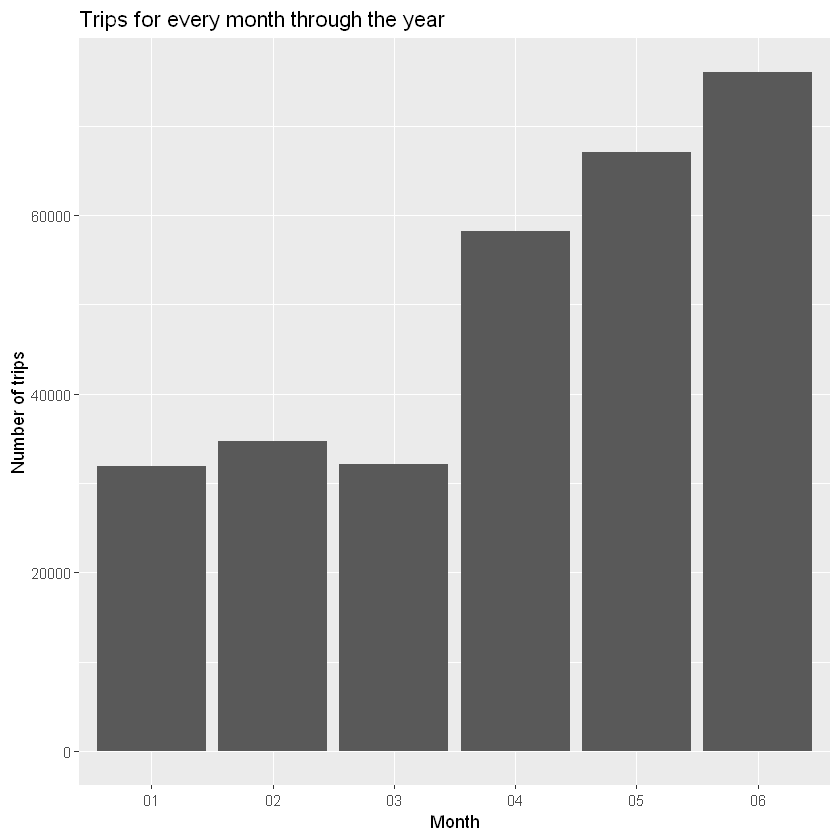

```r
ggplot(aes(x = month), data = nyc) +
    geom_histogram(stat="count") +
    ggtitle('Trips for every month through the year')+
    xlab('Month') +
    ylab('Number of trips')
```

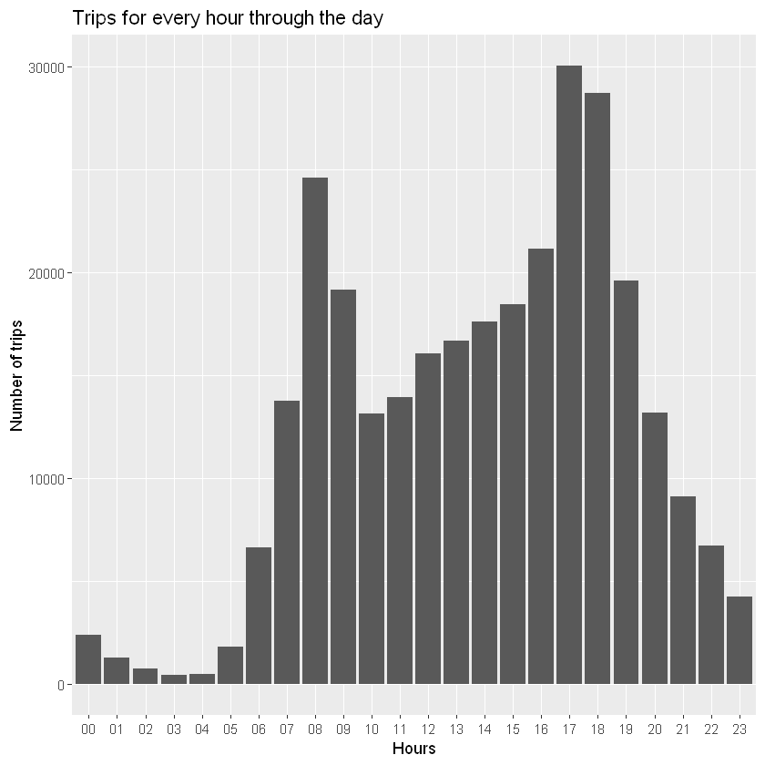

```r
ggplot(aes(x = Time), data = nyc) +
    geom_histogram(stat="count") +
    ggtitle('Trips for every hour through the day')+
    xlab('Hours') +
    ylab('Number of trips')
```

## Answer: (for NYC)

#### As we can see, the number of trips increases while the year moves forward, the weather becomes warmer and the summer arrives.

#### There are several peaks at 8 AM, 5 PM and 6 PM. They maybe happenning as the students and some of the employees go to whether school or work by bikes. This is predictable for students, but the employees behavior may have several causes; the cost of public trasportation, one may be a atheletic.

## Exploring time for Chicago

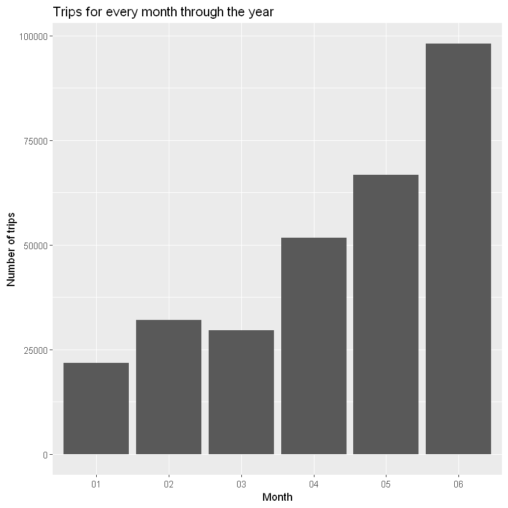

```r
ggplot(aes(x = month), data = chicago) +
    geom_histogram(stat="count") +
    ggtitle('Trips for every month through the year')+
    xlab('Month') +
    ylab('Number of trips')
```

[figure not shown]

```r
ggplot(aes(x = Time), data = nyc) +
    geom_histogram(stat="count") +
    ggtitle('Trips for every hour through the day')+
    xlab('Hours') +
    ylab('Number of trips')
```

## Exploring time for Washington

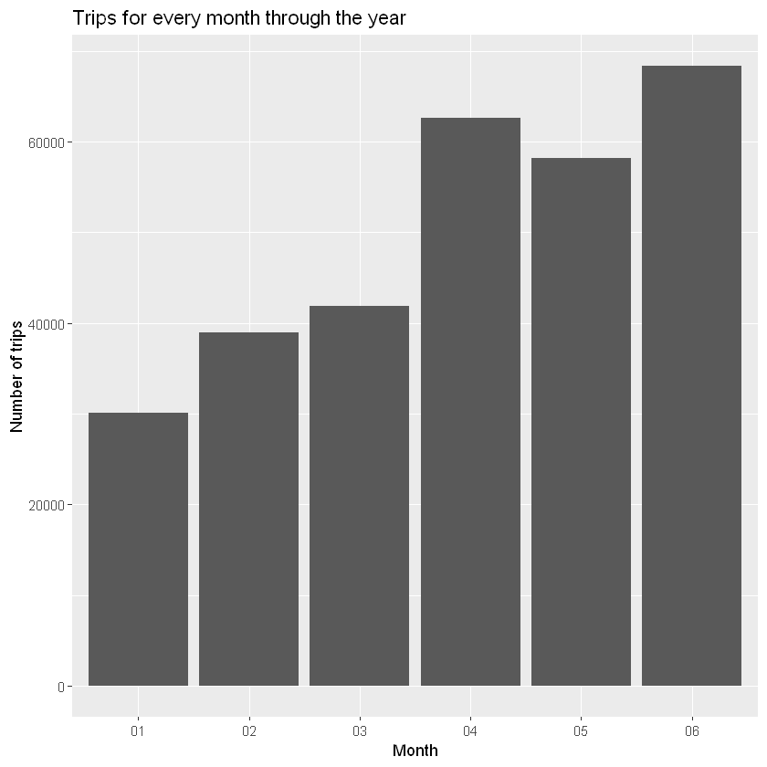

```r
ggplot(aes(x = month), data = washington) +
    geom_histogram(stat="count") +
    ggtitle('Trips for every month through the year')+
    xlab('Month') +
    ylab('Number of trips')
```

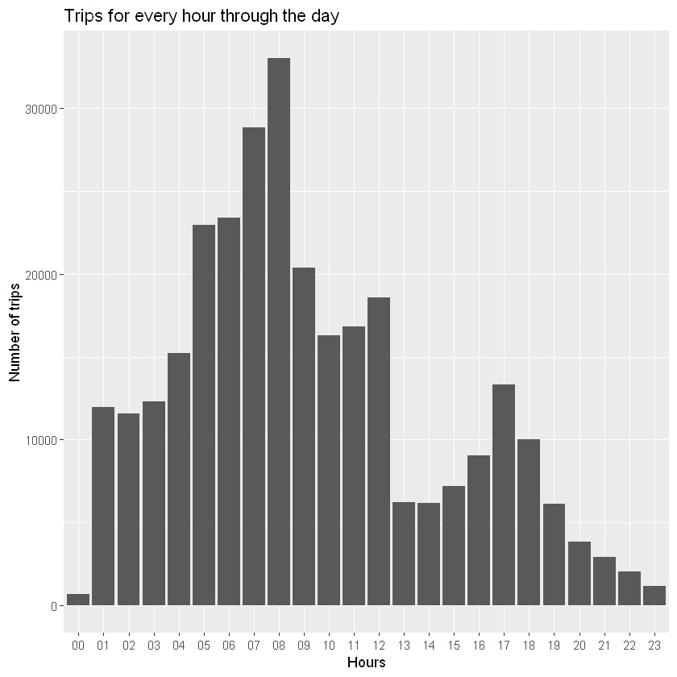

```r
ggplot(aes(x = Time), data = washington) +
    geom_histogram(stat="count") +
    ggtitle('Trips for every hour through the day')+
    xlab('Hours') +
    ylab('Number of trips')
```

## Answer: (for Washington)

### This is a little awkward and unexpected. People in Washington are active in early hours of the day, but in monthly basis, they are doing as expected.

## Question 3: What is the most popular age and gender for bikers?

## Exploring user info

#### Counts for each user type for each city

```r
## for nyc
table(nyc$User.Type)
```

```
             Customer Subscriber
       692      30159     269149
```

```r
## for chicago
table(chicago$User.Type)
```

```
  Customer  Dependent Subscriber
     61110          1     238889
```

```r
## for washington
table(washington$User.Type)
```

```
  Customer Subscriber
     79214     220786
```

## Answer:

#### As we observe, subscribers who already have the habit of riding bikes tend to do it more often than customers who may be just in a picnic or something like that.

### Studying gender and year of birth

[output not shown]

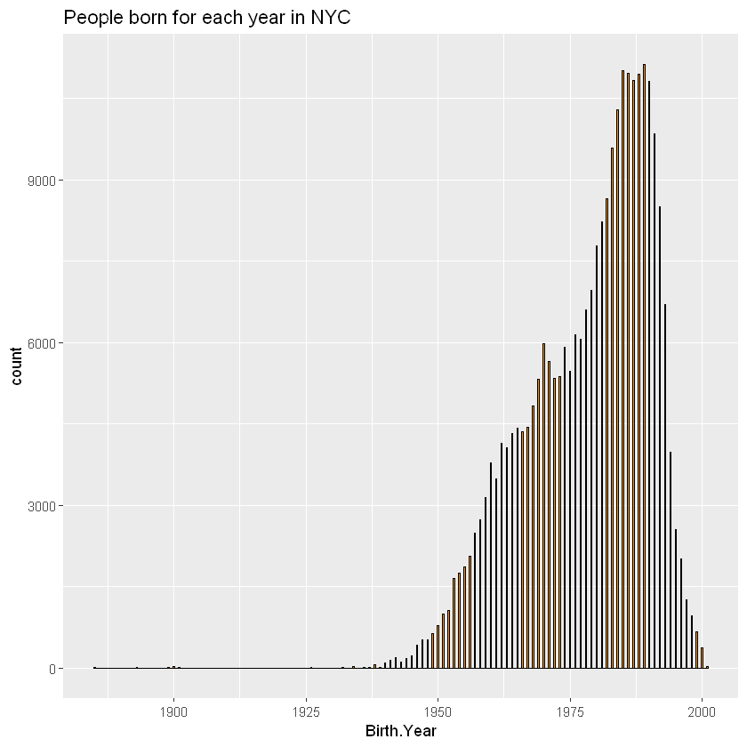

```r
###qplot(x = , Birth.Year, data = nyc, binwidth= 0.25) +
###    scale_x_continuous(limits=c(1950,2010), breaks = seq(1950,2010,5))+
###    main('People born for each year in NYC')+
###    ylab('No. of people')

ggplot(aes(x = Birth.Year), data = nyc) +
    geom_histogram(binwidth = .25, color = 'black', fill = '#F79420') +
    ggtitle('People born for each year in NYC')
    xlab('year') +
    ylab('No. of people')
```

```r
summary(nyc$Birth.Year)
```

```
   Min. 1st Qu.  Median    Mean 3rd Qu.    Max.    NA's
   1885    1970    1981    1978    1988    2001   28220
```

```r
table(nyc$Gender)
```

```
       Female   Male
 29209  66783 204008
```

## Answer: (for NYC)

#### No child born after 2001 ride any bike, and the more ofter bikers are the 80s born children, who are in their 30s now

[output not shown]

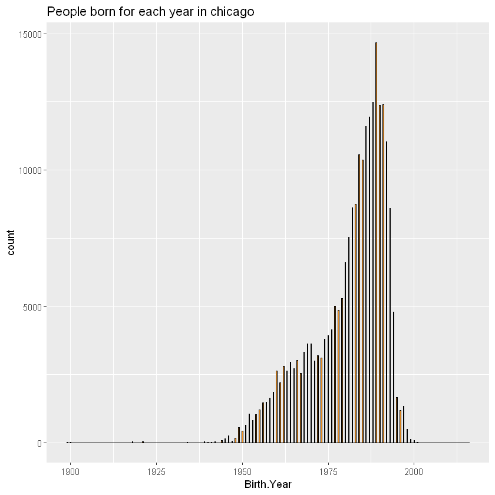

```r
###qplot(x = , Birth.Year, data = chicago, binwidth= 0.25) +
###    scale_x_continuous(limits=c(1950,2010), breaks = seq(1950,2010,5))+
###    main('people born for each year in Chicago')
###    ylab('No. of people')

ggplot(aes(x = Birth.Year), data = chicago) +
    geom_histogram(binwidth = .25, color = 'black', fill = '#F79420') +
    ggtitle('People born for each year in chicago')
    xlab('year') +
    ylab('No. of people')
```

```r
summary(chicago$Birth.Year)
```

```
   Min. 1st Qu.  Median    Mean 3rd Qu.    Max.    NA's
   1899    1975    1984    1981    1989    2016   61019
```

```r
table(nyc$Gender)
```

[output not shown]

## Answer: (for chicago)

#### No child born after 2001 ride any bike like NYC but a toddler born in 2016, and the more ofter bikers are the late 80s born children, who are in their early 30s now.

## Question 4: What's the most common start and end station in NYC?

```r
Popular.station= function(column){
    return(as.data.frame(table(column)))
}
```

```r
Popular.station(nyc$Start.Station)
```

| column | Freq |
| --- | --- |
| 1 Ave & E 16 St | 1274 |
| 1 Ave & E 18 St | 969 |
| 1 Ave & E 30 St | 898 |
| 1 Ave & E 44 St | 582 |
| 1 Ave & E 62 St | 760 |
| 1 Ave & E 68 St | 1145 |
| 1 Ave & E 78 St | 758 |
| 1 Ave & E 94 St | 220 |
| 1 Pl & Clinton St | 115 |
| 10 Hudson Yards | 52 |
| 10 St & 5 Ave | 117 |
| 10 St & 7 Ave | 163 |
| 11 Ave & W 27 St | 1018 |
| 11 Ave & W 41 St | 846 |
| 11 Ave & W 59 St | 802 |
| 12 Ave & W 40 St | 1489 |
| 12 St & 4 Ave | 64 |
| 14 St & 5 Ave | 192 |
| 14 St & 7 Ave | 171 |
| 2 Ave & E 104 St | 132 |
| 2 Ave & 9 St | 74 |
| 2 Ave & E 31 St | 773 |
| 2 Ave & E 96 St | 250 |
| 2 Ave & E 99 St | 86 |
| 21 St & 41 Ave | 5 |
| 21 St & 43 Ave | 44 |
| 21 St & Queens Plaza North | 84 |
| 3 Ave & 14 St | 89 |
| 3 Ave & E 100 St | 41 |
| 3 Ave & E 62 St | 368 |
| ... | ... |
| W 89 St & Columbus Ave | 313 |
| W 90 St & Amsterdam Ave | 215 |
| W 92 St & Broadway | 340 |
| W 95 St & Broadway | 405 |
| W Broadway & Spring St | 916 |
| Warren St & Church St | 559 |
| Warren St & Court St | 228 |
| Washington Ave & Greene Ave | 147 |
| Washington Ave & Park Ave | 225 |
| Washington Park | 200 |
| Washington Pl & 6 Ave | 549 |
| Washington Pl & Broadway | 783 |
| Washington St & Gansevoort St | 645 |
| Water - Whitehall Plaza | 335 |
| Watts St & Greenwich St | 636 |
| West Drive & Prospect Park West | 390 |
| West End Ave & W 107 St | 160 |
| West End Ave & W 94 St | 258 |
| West St & Chambers St | 1968 |
| West Thames St | 702 |
| William St & Pine St | 369 |
| Willoughby Ave & Hall St | 293 |
| Willoughby Ave & Tompkins Ave | 74 |
| Willoughby Ave & Walworth St | 104 |
| Willoughby St & Fleet St | 395 |
| Wolcott St & Dwight St | 33 |
| Wyckoff St & 3 Ave | 155 |
| Wythe Ave & Metropolitan Ave | 549 |
| Yankee Ferry Terminal | 105 |
| York St & Jay St | 590 |

```r
Popular.station(nyc$End.Station)
```

| column | Freq |
| --- | --- |
| 1 Ave & E 16 St | 1266 |
| 1 Ave & E 18 St | 923 |
| 1 Ave & E 30 St | 895 |
| 1 Ave & E 44 St | 609 |
| 1 Ave & E 62 St | 684 |
| 1 Ave & E 68 St | 1110 |
| 1 Ave & E 78 St | 701 |
| 1 Ave & E 94 St | 216 |
| 1 Pl & Clinton St | 117 |
| 10 Hudson Yards | 32 |
| 10 St & 5 Ave | 79 |
| 10 St & 7 Ave | 143 |
| 11 Ave & W 27 St | 1021 |
| 11 Ave & W 41 St | 912 |
| 11 Ave & W 59 St | 774 |
| 12 Ave & W 40 St | 1602 |
| 12 St & 4 Ave | 68 |
| 14 St & 5 Ave | 159 |
| 14 St & 7 Ave | 160 |
| 2 Ave & E 104 St | 142 |
| 2 Ave & 9 St | 90 |
| 2 Ave & E 31 St | 772 |
| 2 Ave & E 96 St | 277 |
| 2 Ave & E 99 St | 99 |
| 21 St & 41 Ave | 10 |
| 21 St & 43 Ave | 51 |
| 21 St & Queens Plaza North | 68 |
| 3 Ave & 14 St | 95 |
| 3 Ave & E 100 St | 53 |
| 3 Ave & E 62 St | 357 |
| ... | ... |
| W 89 St & Columbus Ave | 271 |
| W 90 St & Amsterdam Ave | 222 |
| W 92 St & Broadway | 293 |
| W 95 St & Broadway | 381 |
| W Broadway & Spring St | 994 |
| Warren St & Church St | 513 |
| Warren St & Court St | 214 |
| Washington Ave & Greene Ave | 141 |
| Washington Ave & Park Ave | 249 |
| Washington Park | 172 |
| Washington Pl & 6 Ave | 539 |
| Washington Pl & Broadway | 825 |
| Washington St & Gansevoort St | 662 |
| Water - Whitehall Plaza | 363 |
| Watts St & Greenwich St | 647 |
| West Drive & Prospect Park West | 382 |
| West End Ave & W 107 St | 150 |
| West End Ave & W 94 St | 280 |
| West St & Chambers St | 1968 |
| West Thames St | 707 |
| William St & Pine St | 372 |
| Willoughby Ave & Hall St | 286 |
| Willoughby Ave & Tompkins Ave | 87 |
| Willoughby Ave & Walworth St | 111 |
| Willoughby St & Fleet St | 327 |
| Wolcott St & Dwight St | 28 |
| Wyckoff St & 3 Ave | 116 |
| Wythe Ave & Metropolitan Ave | 610 |
| Yankee Ferry Terminal | 99 |
| York St & Jay St | 654 |